# Sleep and Health analysis

Author

Cheyenne Erickson

# Data Exploration Project on Sleep and Health Statistics

```r
library(dplyr)
library(ggcorrplot)
library(ggplot2)
library(ggpubr)
library(corrplot)
library(reticulate)
```

Reading Health and Sleep data 2024 from kaggle.com  
Owner : Orvile  
Funding: University of Oxford

```r
my_data <- read.csv("C:/Users/Cheye/OneDrive/Documents/Personal Data Projects/Health and Sleep relation/Sleep_health_and_lifestyle_dataset.csv")
#print(my_data)
```

## Correlation Heat Map

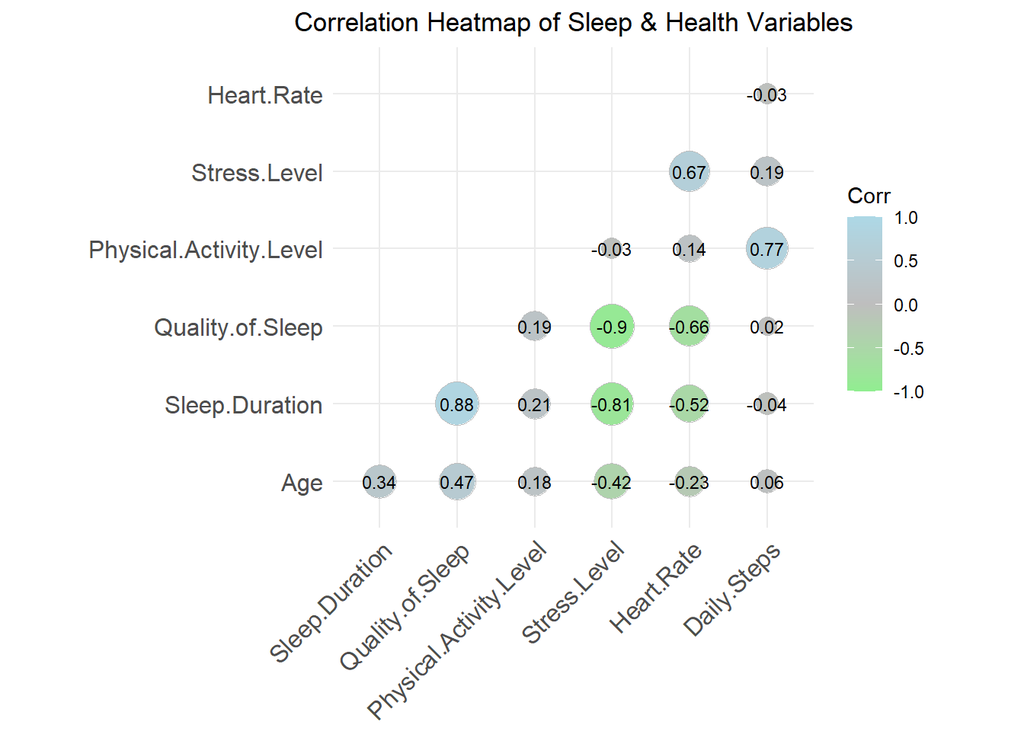

```r
#collect numerical data
numeric_data <- my_data %>%
  select(Age, Sleep.Duration, Quality.of.Sleep, Physical.Activity.Level,
         Stress.Level, Heart.Rate, Daily.Steps)

#calculate correlation matrix
cor_matrix <- cor(numeric_data, use = "complete.obs")
## "complete.obs" makes it so only rows with no missing values are used.

#make map
ggcorrplot(cor_matrix,
           method = "circle",
           type = "lower",
           lab = TRUE,
           lab_size = 3,
           colors = c("light green", "gray", "light blue"),
           title = "Correlation Heatmap of Sleep & Health Variables",
           ggtheme = theme_minimal() +
             theme(
               plot.title = element_text(hjust = 0.5)
             ))
```

# Observations from HeatMap

## Strong Correlations (.7 - 1):

- Quality of Sleep and Sleep Duration : positive relationship
- Stress Level and Sleep Duration : negative relationship
- Stress level and Quality of sleep : negative relationship
- Daily Steps and Physical Activity level : positive relationship

## Moderate Correlations (.4 - .69):

- Quality of Sleep and Age : Positive relationship
- Stress Level and Age : negative relationship

# Bar graph showing Stress Level and Occupation

```r
# data set with only Stress Level and Occupation columns
stress_occupation_data <- my_data%>%
  select(Stress.Level, Occupation)
#print(stress_occupation_data)


# data set grouped by occupation and average and sum statistics
stress_stats <- stress_occupation_data %>%
  group_by(Occupation) %>%
  summarise(Avg_Stress_Level = mean(Stress.Level, na.rm = TRUE),
            Sum_Stress_Level = sum(Stress.Level, na.rm = TRUE))

#print(stress_stats)
```

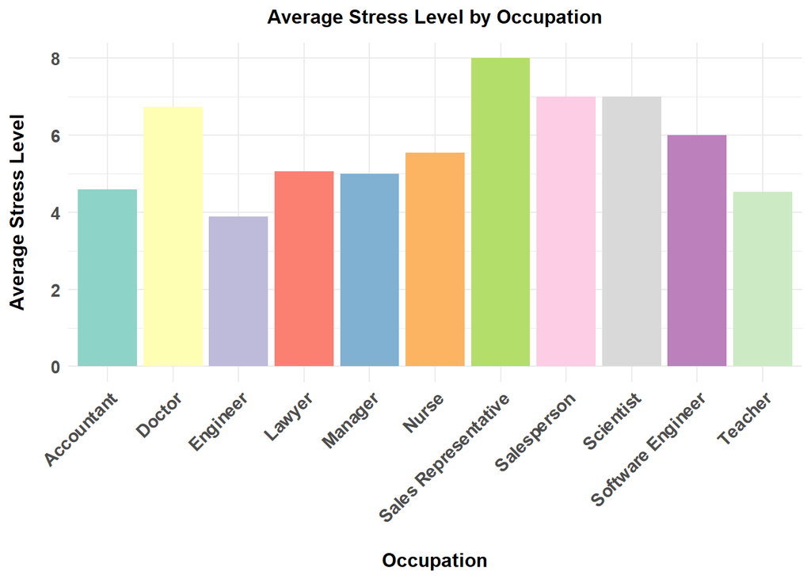

```r
#bar graph creation
ggplot(stress_stats, aes(x = Occupation, y = Avg_Stress_Level, fill = Occupation)) +
  geom_bar(stat = "identity") +
  theme_minimal() +
  labs(
    title = "Average Stress Level by Occupation",
    x = "Occupation",
    y = "Average Stress Level"
  ) +
  theme(
    axis.text.x = element_text(angle = 45, hjust = 1, size = 11, face = "bold"),
    axis.text.y = element_text(size = 11, face = "bold"),
    axis.title.x = element_text(margin = margin(t = 16), face = "bold", size = 12),
    axis.title.y = element_text(margin = margin(r = 15), face = "bold", size = 12),
    plot.title = element_text(size = 12, face = "bold", hjust = 0.5, margin = margin(b = 10)),
    legend.position = "none"
    ) +
  scale_fill_brewer(palette = "Set3")
```

# Question:

## Do people with sleep disorders (e.g., insomnia, apnea) have significantly higher stress levels?

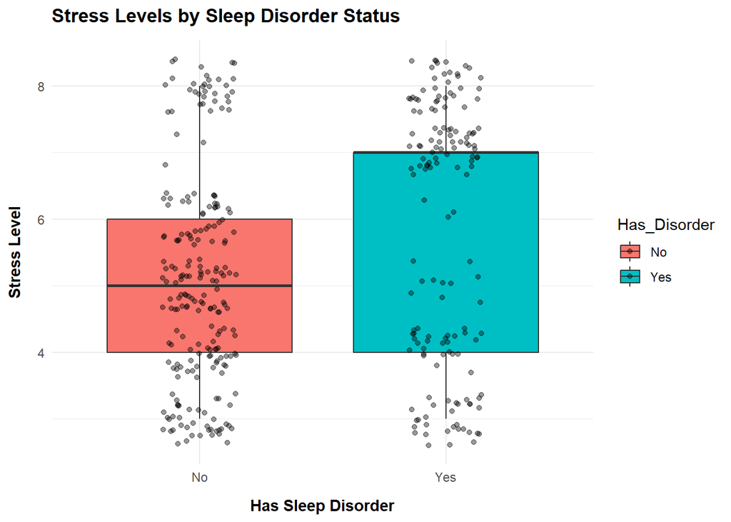

```r
# make new column in data stating if instance has sleeping disorder
grouped_data <- my_data %>%
  mutate(Has_Disorder = ifelse(Sleep.Disorder == "None", "No", "Yes"))
#print(grouped_data)

# Make box plot to visualize
# ggplot(grouped_data, aes(x = Has_Disorder, y = Stress.Level, fill = Has_Disorder)) +
#   geom_boxplot() +
#   labs(title = "Stress Levels by Sleep Disorder Status", x = "Has Sleep Disorder", y = "Stress Level") +
#   theme_minimal()

ggplot(grouped_data, aes(x = Has_Disorder, y = Stress.Level, fill = Has_Disorder)) +
  geom_boxplot(outlier.colour = "darkred", outlier.shape = 16, outlier.size = 2) +
  labs(title = "Stress Levels by Sleep Disorder Status", x = "Has Sleep Disorder", y = "Stress Level") +
  geom_jitter(width = 0.15, alpha = 0.4, color = "black") +
  theme_minimal() +
  theme(
    axis.title.x = element_text(face = "bold", margin = margin(t = 10)),
    axis.title.y = element_text(face = "bold", margin = margin( r= 10)),
    plot.title = element_text(face = "bold", margin = margin(b=10))

  )
```

## First Observation:

The distribution of stress level within those who have stress disorder have the median line at the top of the box plot, likely do to ties or skewed data.

```r
grouped_data %>%
  group_by(Has_Disorder) %>%
  summarise(
    Min = min(Stress.Level),
    Q1 = quantile(Stress.Level, 0.25),
    Median = median(Stress.Level),
    Q3 = quantile(Stress.Level, 0.75),
    Max = max(Stress.Level),
    Mean = mean(Stress.Level),
    Count = n()
  )
```

```
# A tibble: 2 × 8
  Has_Disorder   Min    Q1 Median    Q3   Max  Mean Count
  <chr>        <int> <dbl>  <int> <dbl> <int> <dbl> <int>
1 No               3     4      5     6     8  5.11   219
2 Yes              3     4      7     7     8  5.77   155
```

yes disorder: - Q2 and Q3 are the same hence the weird box. This shows that the data is skewed - 25% of people in this category had stress levels < 4 - 50% and 75% of people in this category had stress levels < 7 - median = 7, implying left-skewed data

no disorder: - seems normally distributed at a glance - 25% of people in this category had stress levels < 4 - 50% of people in this category had stress levels < 5 - 75% of the people in this category had stress levels < 6

general: medians and distributions are noticeably different, but not variability

# Testing if Data from Two Groups are Normal

To determine the appropriate statistical test to answer the question, Do people with sleep disorders (e.g., insomnia, apnea) have significantly higher stress levels, I first want to check if the data from the two groups are Normal.

## statistical check:

```r
# testing if the data is significantly different from normal data
shapiro.test(grouped_data$Stress.Level[grouped_data$Has_Disorder == "No"])
```

```
    Shapiro-Wilk normality test

data:  grouped_data$Stress.Level[grouped_data$Has_Disorder == "No"]
W = 0.89339, p-value = 2.387e-11
```

```r
shapiro.test(grouped_data$Stress.Level[grouped_data$Has_Disorder == "Yes"])
```

```
    Shapiro-Wilk normality test

data:  grouped_data$Stress.Level[grouped_data$Has_Disorder == "Yes"]
W = 0.82214, p-value = 1.897e-12
```

The Shapiro Wilk test for both groups produced a p-value < 0.5 so the hypothesis that the data are normal is rejected.

## Visual Check:

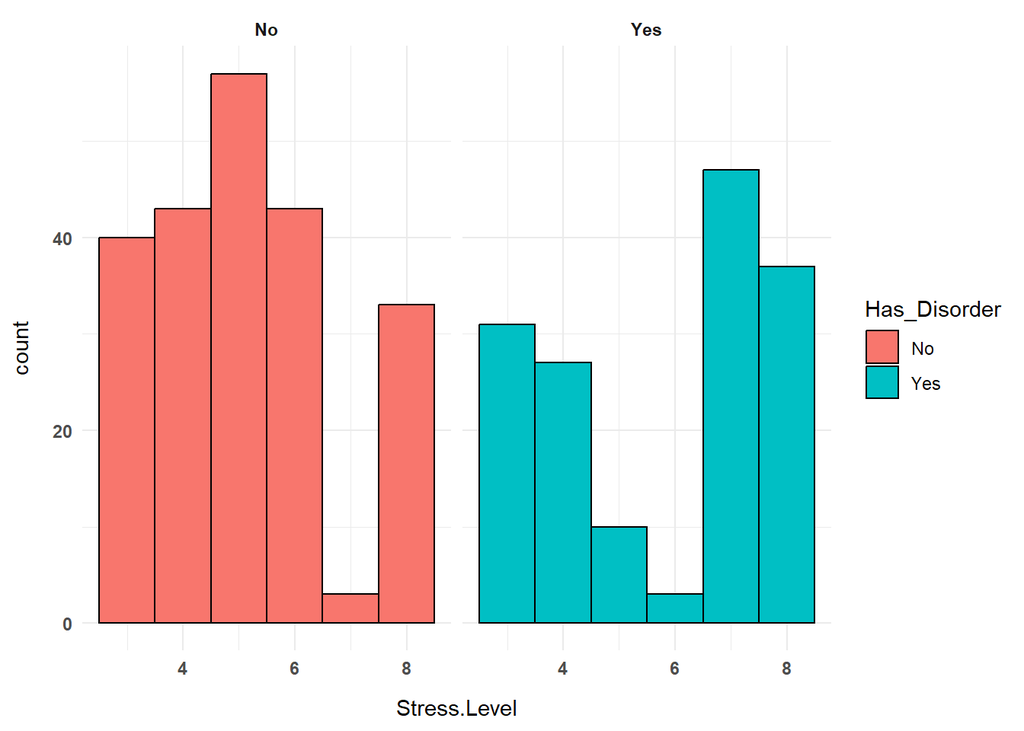

```r
# Histogram
ggplot(grouped_data, aes(x = Stress.Level, fill = Has_Disorder)) +
  geom_histogram(binwidth = 1, position = "dodge", color = "black") +
  facet_wrap(~Has_Disorder) +
  theme_minimal()+
  theme(
    axis.text.x = element_text(face = "bold"),
    axis.text.y = element_text(face = "bold"),
    axis.title.x = element_text(margin = margin( t= 10)),
    axis.title.y = element_text(margin = margin(r=10)),
    strip.text = element_text(face = "bold")
    )
```

No bell shaped curve, supporting earlier conclusion from Shapiro-Wilk normality test

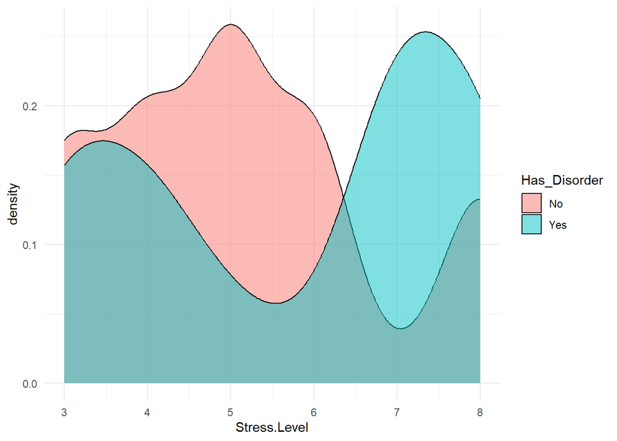

```r
# Or Density plot
ggplot(grouped_data, aes(x = Stress.Level, fill = Has_Disorder)) +
  geom_density(alpha = 0.5) +
  theme_minimal()
```

The Density plot reveals Same thing even clearer

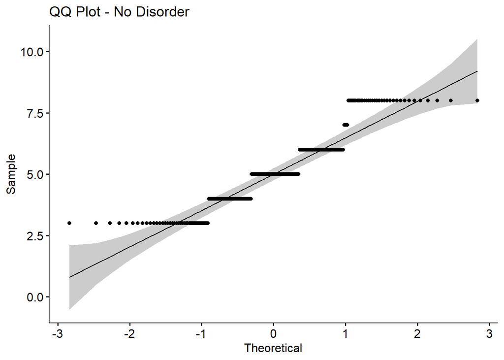

```r
#QQ plot
ggqqplot(grouped_data$Stress.Level[grouped_data$Has_Disorder == "No"], title = "QQ Plot - No Disorder")
```

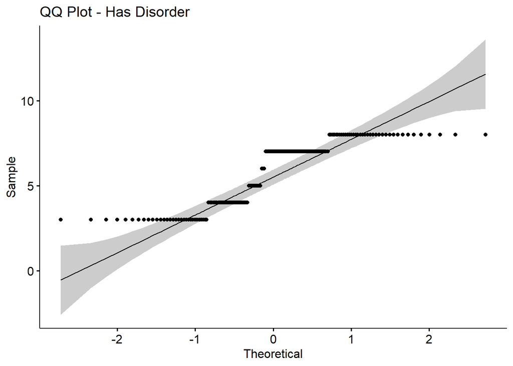

```r
ggqqplot(grouped_data$Stress.Level[grouped_data$Has_Disorder == "Yes"], title = "QQ Plot - Has Disorder")
```

## Non-Parametric Testing

Since the distributions of stress levels within those with and without sleep disorders are not normally distributed I will use Non-Parametric testing to answer the question.

Use Wilcoxon Ranked-Sum test since we have two independent groups.

```r
wilcox.test(Stress.Level ~ Has_Disorder, data = grouped_data)
```

```
    Wilcoxon rank sum test with continuity correction

data:  Stress.Level by Has_Disorder
W = 13901, p-value = 0.002467
alternative hypothesis: true location shift is not equal to 0
```

The test revealed a p-value < .05 so we reject the hypothesis that the mean stress levels in both groups are the same

A.K.A There is a significant difference in stress levels between those who have sleep disorders and those who do not.

# Question:

## Can I predict stress level based on physical activity, sleep duration, heart rate, age, quality of sleep, daily steps, occupation, and sleep disorder?

```r
# first, qualitative data must be transformed
grouped_data$Occupation <- as.factor(grouped_data$Occupation)
grouped_data$Has_Disorder <- as.factor(grouped_data$Has_Disorder)


#regression model
model <- lm(Stress.Level ~ Physical.Activity.Level + Sleep.Duration + Heart.Rate +
              Age + Quality.of.Sleep + Daily.Steps + Occupation + Has_Disorder,
            data = grouped_data)
summary(model)
```

```
Call:
lm(formula = Stress.Level ~ Physical.Activity.Level + Sleep.Duration +
    Heart.Rate + Age + Quality.of.Sleep + Daily.Steps + Occupation +
    Has_Disorder, data = grouped_data)

Residuals:
    Min      1Q  Median      3Q     Max
-1.8425 -0.1096  0.0000  0.1212  1.7246

Coefficients:
                                 Estimate Std. Error t value Pr(>|t|)
(Intercept)                     1.000e+01  1.132e+00   8.838  < 2e-16 ***
Physical.Activity.Level        -6.159e-03  2.523e-03  -2.441  0.01515 *
Sleep.Duration                 -5.037e-01  7.999e-02  -6.297 8.93e-10 ***
Heart.Rate                      6.279e-02  1.155e-02   5.437 1.01e-07 ***
Age                             2.953e-02  5.504e-03   5.366 1.46e-07 ***
Quality.of.Sleep               -1.073e+00  6.971e-02 -15.395  < 2e-16 ***
Daily.Steps                     2.257e-04  3.089e-05   7.309 1.79e-12 ***
OccupationDoctor                7.478e-01  1.076e-01   6.949 1.76e-11 ***
OccupationEngineer              3.361e-01  1.093e-01   3.077  0.00226 **
OccupationLawyer                4.588e-01  1.005e-01   4.565 6.88e-06 ***
OccupationManager              -9.538e-01  4.530e-01  -2.105  0.03595 *
OccupationNurse                -1.719e-01  1.216e-01  -1.413  0.15841
OccupationSales Representative -1.165e+00  3.559e-01  -3.275  0.00116 **
OccupationSalesperson          -6.896e-03  1.407e-01  -0.049  0.96095
OccupationScientist            -1.372e+00  2.521e-01  -5.444 9.70e-08 ***
OccupationSoftware Engineer    -2.453e-01  2.402e-01  -1.021  0.30778
OccupationTeacher              -9.613e-01  1.249e-01  -7.694 1.41e-13 ***
Has_DisorderYes                -2.273e-01  8.219e-02  -2.766  0.00597 **
---
Signif. codes:  0 '***' 0.001 '**' 0.01 '*' 0.05 '.' 0.1 ' ' 1

Residual standard error: 0.4392 on 356 degrees of freedom
Multiple R-squared:  0.9415,    Adjusted R-squared:  0.9387
F-statistic: 337.2 on 17 and 356 DF,  p-value: < 2.2e-16
```

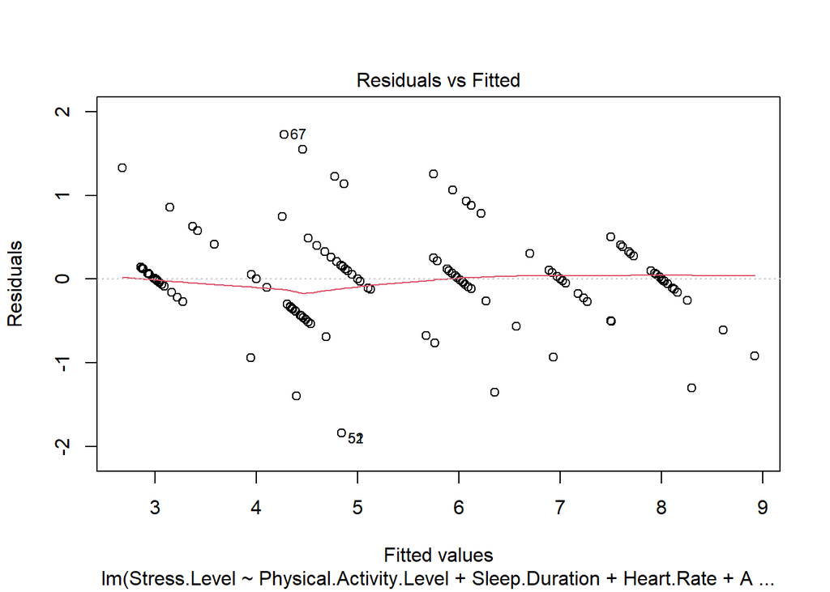

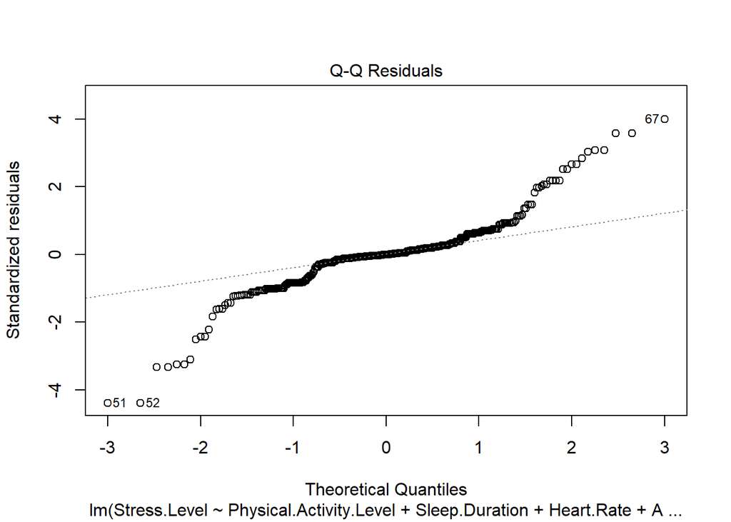

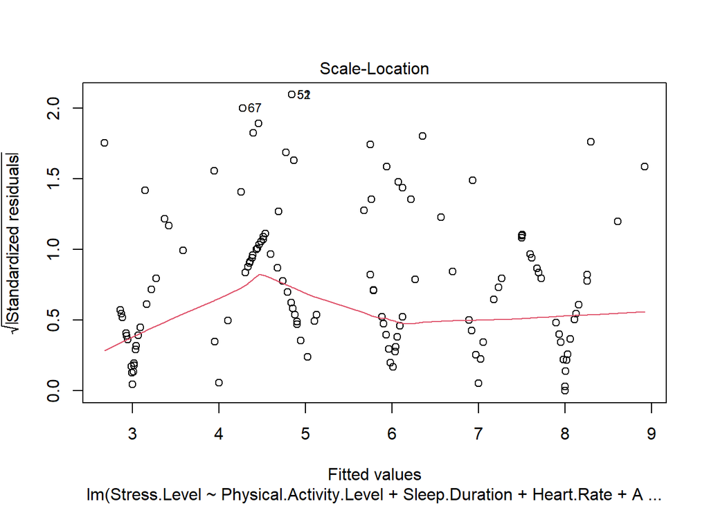

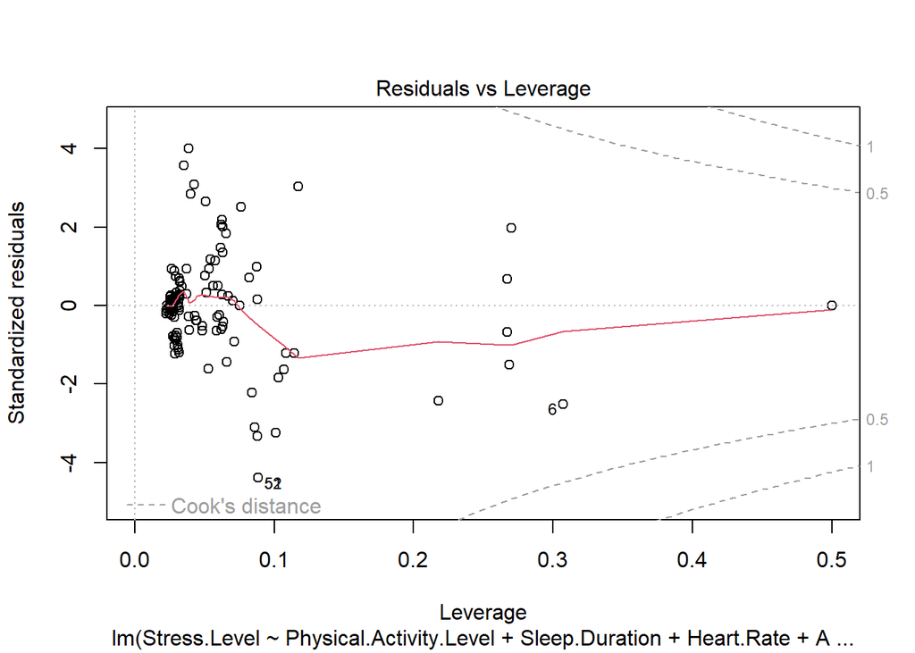

```r
plot(model)
```

## Model as Function

```r
# Get the coefficients
coef_values <- coef(model)

# Build equation as a string
equation <- paste0(
  "Stress.Level = ",
  round(coef_values[1], 3), " + ",
  paste(
    paste0(round(coef_values[-1], 3), " * ", names(coef_values[-1])),
    collapse = " + "
  )
)

equation
```

[output not shown]

## Summary Observations

R-Squared value of 0.9415, meaning this model explains 94.15% of the variance in stress level. The P-value of < 0.05 says that the model is statistically significant and not just noise. The predictors in the summary with *** are highly significant (p <.001), ** is significant (p < .01), and * is somewhat significant (p <.05). The first column of integers is the regression coefficient (how much stress level changes for 1 unit change in predictor variable), the second column is the standard error of the estimate, and the third column is the test statistic.

The regression coefficient for Has_DisorderYes is negative which is not expected since earlier we discovered in the boxplot that those with sleeping disorders had higher stress levels, This could be from other variables suppressing Has_DisorderYes effect. Below I will check the correlation between Has_DisorderYes and other variables.

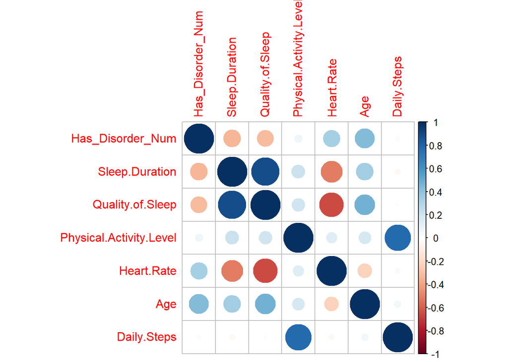

```r
# Convert Has_Disorder to numeric for correlation purposes
grouped_data$Has_Disorder_Num <- ifelse(grouped_data$Has_Disorder == "Yes", 1, 0)

cor_matrix <- cor(grouped_data[, c("Has_Disorder_Num", "Sleep.Duration", "Quality.of.Sleep", "Physical.Activity.Level", "Heart.Rate", "Age", "Daily.Steps")])
corrplot(cor_matrix, method = "circle")
```

This correlation map shows that Has_Disorder has a negative relationship with sleep duration and quality of sleep, which are stronger predictors in the model. The unique part of Has_Disorder that is not explained by sleep or health appears to be slightly negative. I will keep Has_disorder in the model, while keeping this in mind.

Now that the model is validated, I will create a stress predictor model using python.

## Stress Predictor

```python
import pandas as pd
from sklearn.linear_model import LinearRegression
from sklearn.preprocessing import OneHotEncoder
from sklearn.compose import ColumnTransformer
from sklearn.pipeline import Pipeline


grouped_data_py = r.grouped_data  # Access the R variable directly

X = grouped_data_py[['Physical.Activity.Level', 'Sleep.Duration', 'Heart.Rate',
                     'Age', 'Quality.of.Sleep', 'Daily.Steps', 'Occupation', 'Has_Disorder']]
y = grouped_data_py['Stress.Level']

# Define preprocessing for categorical variables
categorical_features = ['Occupation', 'Has_Disorder']
categorical_transformer = OneHotEncoder(handle_unknown='ignore')

# Combine preprocessing with model
preprocessor = ColumnTransformer(
    transformers=[
        ('cat', categorical_transformer, categorical_features)
    ],
    remainder='passthrough'  # Keep other columns as they are
)

# Build pipeline
model = Pipeline(steps=[
    ('preprocessor', preprocessor),
    ('regressor', LinearRegression())
])

# Fit the model
model.fit(X, y)
```

```
Pipeline(steps=[('preprocessor',
                 ColumnTransformer(remainder='passthrough',
                                   transformers=[('cat',
                                                  OneHotEncoder(handle_unknown='ignore'),
                                                  ['Occupation',
                                                   'Has_Disorder'])])),
                ('regressor', LinearRegression())])
```

```python
# ---- Predict from manual input ----
# Example: You can replace these values
manual_input = pd.DataFrame([{
    'Physical.Activity.Level': 5,
    'Sleep.Duration': 7.5,
    'Heart.Rate': 72,
    'Age': 30,
    'Quality.of.Sleep': 8,
    'Daily.Steps': 8000,
    'Occupation': 'Engineer',
    'Has_Disorder': 'No'
}])

predicted_stress = model.predict(manual_input)
print(f"Predicted Stress Level (manual input): {predicted_stress[0]:.2f}")
```

```
Predicted Stress Level (manual input): 5.16
```

```python
# ---- Predict using existing dataset row ----
row_index = 1  # Change this to test different rows
existing_row = X.iloc[[ row_index]]
predicted_existing = model.predict(existing_row)
print(f"Predicted Stress Level (row index {row_index}): {predicted_existing[0]:.2f}")
```

```
Predicted Stress Level (row index 1): 8.61
```

This python code can be used to predict stress levels based on user manual input for the predictor variables, or the code can be used to predict stress levels in the existing data set.